# Coal Model

**1. Predicting Job Losses in the United States Coal Industry**

All work (data collection, data cleaning, model creation, and prediction) done together by Javi and Priyanka

**1.1 ABSTRACT**

**1.2 PROJECT BACKGROUND**

Central to decarbonization is the timely, well-planned phase out of coal production. Currently, coal accounts for roughly a third of global energy supply and contributes 45% of global CO2 emissions. The world’s decarbonization pathway is clear, especially in the energy sector. Promising renewable technology like wind and solar power are the cheapest sources of energy compared to coal in most major countries. Though the pace of this transition continues to fall behind net-zero targets, the clean energy transition seems inevitable, with renewable installation growth surpassing all projections. Coal industries across the world are financially insolvent, surviving only due to large subsidies by national governments, massive layoffs, and mechanization. The industry is associated with myriad community health, water pollution, and air pollution impacts, contributing to at least 800,000 premature deaths a year globally and many millions more illnesses. A central question is thus how to make this transition just - the workers that have powered our economy are facing job loss, structural economic transition, and uncertainty around the future of their work. The transition to low-carbon, environmentally and socially sustainable economies can be a strong driver of job creation, social justice and poverty eradication, if properly managed with the engagement of governments, workers, and unions.

Often coal communities that are most at risk of economic dislocation are geographically concentrated in a few parts of the country, with the coal industry a main economic activity and cultural identity for the community. Coal transitions in recent memory have seen significant drops in employment over a period of 10 years or less. However, transitioning thousands of employees into new employment cannot happen overnight. Thus, thoughtful planning and the proactive incorporation of opportunities of a renewable economy into a just transition are crucial to addresses fears of job loss and local economic decline. However, this also provides an opportunity to work creatively with communities to build new industries and employment opportunities. Moreover, it is increasingly clear that justice must be integral to the broader success of the climate movement. Without it, there can be no consensus between communities, sub-national, and national entities on the needed cooperation to mitigate and adapt to a climate changing world. This dynamic is evident at international negotiations like the UNFCC Conference of Parties, where developing and developed countries are often at a stalemate on climate cooperation because there is reticence from Western nations to shoulder historical responsibility and provide the funding needed for developing countries to successfully make the transitions away from fossil fuels.

In order to incorporate opportunities of a renewable economy, there must be reliable quantative analysis about the range of employment opportunities that are possible for countries and states through investment in growing the renewables industry. At the same time, there also must be proactive planning to draw down industries like coal, and in order to do so it is important to understand how many jobs exist in the industry, how many are going to be lost or gained and on what timescale. Understanding those trends, whether it be gains in renewables or losses in coal, can help support the interactions with communities to plan a just transition. It becomes very clear then what resources must be allocated to a region in order to re-skill workers, how much investment must be made in social safety nets to protect transitioning workers, and also identify the potential drivers of job growth in the renewables industry for that area.

Sources:

1. https://www.iea.org/reports/global-energy-co2-status-report-2019
2. https://endcoal.org/health/#:~:text=Coal%20is%20responsible%20for%20over,of%20coal%2Drelated%20air%20pollution.

**1.3 PROJECT OBJECTIVE**

The purpose of this project is to train and evaluate different prediction models to assess job losses and job gains by state in the coal and solar industry respectively. In order to do this, we built two separate models - one for coal and one for solar. Below will be further detailed descriptions about the coal data, data cleaning, and coal models in this notebook and we will also be submitting a separate report for our solar model. This question will answer a three-part resource allocation that was elaborated on in the project background: What is the timeframe of job loss for coal workers in the United States? What are the employment gains to be had from solar installations and how quickly is that industry growing in different regions? How many workers are affected by both transitions (towards solar and away from coal) and what implications does that have for resources allocated in terms of re-skilling, up-skilling, and broader economic diversification of a coal-dependent region?

In many cases the model shows that the areas most heavily invested in coal employment are often not as invested in solar but that is not always true and the model also provides a sense of which coal-dependent states are moving towards a solar industry vs ones that are lagging in their investment. In part it was incredibly challenging to build this model because we couldn't find any previous examples of people using predictive modeling to answer these types of economic questions around employment in different energy sectors.

**1.4 INPUT DATA DESCRIPTION**

The data that we used to build our coal model included the following -

- Bureau of Labor Statistics Data for historic employment (2012-2020) in the coal industry
- Energy Information Data from 2012-2020 on nameplate capacity from the previous year, as well as projected capacity, additions and retirements by state from the previous year. In order to find this data we used the Annual Energy Outlook, the Short Term Energy Outlook, Electric Power Monthly, Electric Power Annual, reported out from the EIA-860 forms.
- Lazard data on levelized costs of energy for coal from 2012-2021. We assumed a constant LCOE for each state based on the yearly value.
- American Community Survey and Historic US Census Data for demographic features including median household income, resident population, population above 25 years, population with educational attainments reaching high school, population with educational attainments reaching an associates degree, and population with educational attainments reaching a bachelor's degree.

**SGSTF of Data Listed Above:**

- **Structure:** For each of our individual data sets (which we merged into one dataframe) the data is grouped by state and fuel source. Each observation in the data frame corresponds to a year and a state, and each column represents either our response variable data or our feature variable data for that state in that year. We downloaded all of these files as Excel files.
- **Granularity:** Each row represents an observation from a state in each year from 2012-2020.
- **Scope:** For our geographic scope, our data covers all states of the United States except for Washington DC, Rhode Island and Vermont which we ultimately removed from our model building process because they had no data relevant to the model's ability to predict - there were no coal jobs in these states, nor any coal capacity, nor any projections for additions or retirements.
- **Temporality:** Our data set covers the years between 2012-2020, and we predicted for the years 2021 and 2022. All predictions were done by state.
- **Faithfulness:** Our demographic data comes from the Census Bureau, which is a government group that collects self-reported data on the population. Given that the data is self reported and voluntarily recorded, our data may be potentially skewed. Our BLS data comes from an annual mail survey of establishments that provides data on employment and wages by occupation and industry for over 800 occupations and for about 400 industries throughout the United States, and similar data for all states and selected metropolitan areas. Similar to the census data, there is potential for the data to be skewed because it is self reported and voluntarily recorded. However, the coal industry jobs data has a history of reporting to the BLS and seems reliable. In contrast, we couldn't use the solar and wind job data from BLS and had to turn to other sources (and exclude a wind model) because the jobs data was underreported for those sectors. Our Lazard data comes from historical averages and cross-validated with other LCOE estimates - little opportunities for data skewing. Finally, our EIA data came from multiple different datasets within the EIA database. Historic nameplate capacity data (for the previous year from our projection year) came from Electric Power Annual and our projected capacity additions and retirements came from the December version of Electric Power Monthly for years 2012-2020. For 2021 data (projecting 2022), we used the latest version of Electric Power Monthly which was released in October. We understand that this is an inconsistency in our data but unfortunately due to the fact that the December version has yet to be released yet, we had to rely on this data for our predictions. All of this data was originally downloaded catagorized by power plant (Form EIA-860) but we did some work in Excel first to sum the capacity, additions and retirements by state througn the use of a pivot table. This data is of course subject to change but because it is based on mandatory reporting at the power plant level, the data for the most part seems to be quite accurate in assessing coal capacity in the country.

**1.5 and 1.6 - DATA CLEANING AND EDA**

Our EDA is not in our coal and solar model files but can be found in a separate file which we plan to submit along with this readout. However, here we will detail our process by which we conducted our Data Cleaning Process and our EDA. We separated these two things from our model notebook because our Cleaning and EDA process was so lengthy and complex. In order to conduct the EDA, we worked in Google Collab because we initially thought it would be easier for the two of us to work on code at the same time. However, this was not the case and we ultimately worked on code together and then inputted into the Google Collab sheet. Before we could merge the data into one dataset, we first needed to clean and conduct an EDA on the four components of our data: Jobs, Nameplate Capacity, Additions + Retirements, and Demographic Data (population, income, educational attainment).

Before we discuss the EDA portion, I'll first outline the ways in which we had to clean our data prior to even importing into a Google Collab notebook. Because there were multiple datasets that we needed to collate for each variable and because each dataset had a different granularity and temporality of features, for example EIA data being catagorized by power plant and demographic data by state, we had to prep a lot of our datasets first in excel in order to get all variables defined by state and year. This included primarily collating yearly datasets into one large dataset and using pivot tables to sum up variables like namelpate capacity, historic addition and retirement as well as projected addition and retirement data by state and year (vs power plant). We also downloaded the full American Community Survey Census Data and created a new dataframe by pulling the specific columns that we wanted to include as demographic information for the years 2012-2020.

There are four components to our EDA file:

*1. EDA Jobs* *2. EDA Nameplate + Demographic* *3. EDA Coal Ret & Add* *4. EDA Solar Ret & Add (Not Relevant for Coal Model)*

EDA Jobs: In this section of the EDA, we downloaded into the notebook the jobs data from 2012-2020 (all different excel spreadsheets coming from BLS). It was easy to manage this section because the datasets were essentially the same, only differing in their input values based on the year. First, we reorganized all the columns so each dataset was in the same order and had the same column names (initially some column names had capital letters and some didnt, or the column representing the same data had a different name depending on the year of the dataset). This was particularly straightforward to coal jobs because all coal jobs are classified under "Coal Mining" and we were able to pull the "total" column for each state for each year from 2012 to 2020.

EDA Nameplate and Demographic: In this section we imported the demographic data by state and year which we had pulled originally from the very large American Community Survey Dataset and pulled the specific columns that we wanted to use as demographic data - median household income, resident population, population over the age of 25, educational attainment levels for high school, associate degree and bachelors degree. In excel we had compiled all that data for each year and state and imported it into our notebook. Similarly, for nameplate capacity data we used the datasets from EIA and did a pivot table to get the summed nameplate capacity data by state and year (using the 8 different datasets). We then uploaded this into our notebook as well. and merged it with the dataframe from Step 1. The output of these steps is a coal dataframe including dataframe (coal and solar) with jobs, nameplate capacity and demographic information for each state, in each year from 2012 to 2020.

At the end we added a column for our LCOE which was constant by state for each year. This dataset had already been copied and prepped previously in Excel so we just merged to our dataframe. The result was the final dataframe which we then used to build and train our model.

**1.7 VISUALIZATIONS, FORECASTING AND PREDICTION MODELING**

This section included reading all our imports in as well as our coal dataframe.

```python
import numpy as np
import pandas as pd
import matplotlib
import matplotlib.pyplot as plt
import csv
from pathlib import Path

import seaborn as sns
sns.set_context("talk")
%matplotlib inline

from sklearn.model_selection import train_test_split
from sklearn.model_selection import train_test_split
from sklearn.linear_model import LinearRegression
from sklearn.linear_model import Ridge
from sklearn.linear_model import Lasso
from sklearn.metrics import mean_squared_error
from sklearn.preprocessing import StandardScaler
from sklearn.model_selection import KFold
from sklearn import neighbors, datasets, preprocessing
from sklearn.model_selection import train_test_split
from sklearn.metrics import accuracy_score
from sklearn.preprocessing import Normalizer
from sklearn.preprocessing import PolynomialFeatures
from sklearn.metrics import accuracy_score
from sklearn.metrics import mean_absolute_error
from sklearn.metrics import r2_score
import statsmodels.api as sm

import warnings
warnings.filterwarnings('ignore')
```

```python
coal = pd.read_csv('DF Coal Final.csv')
coal = coal.loc[coal['PREDICTION YEAR'] != 2021]
```

```python
coal.head()
coal['PREDICTION YEAR'].unique()
```

```
array([2012, 2013, 2014, 2015, 2016, 2017, 2018, 2019, 2020])
```

```python
coal.shape
```

```
(401, 26)
```

```python
coal
```

|  | STATE | TOTAL EMPLOYMENT | PREDICTION YEAR | COAL NAMEPLATE CAPACITY | MEDIAN HOUSEHOLD INCOME (CURRENT INCOME, USD $) | RESIDENT POPULATION | POPULATION (25 YEARS OR OLDER) | EDUCATIONAL ATTAINMENT 25 YEARS OLDER (HIGH SCHOOL) | EDUCATIONAL ATTAINMENT 25 YEARS OR OLDER (ASSOCIATES DEGREE) | EDUCATIONAL ATTAINMENT 25 YEARS OR OLDER (BACHELOR DEGREE) | ... | PROYECTED RET N+6 | PROYECTED RET N+7 | HISTORIC ADDITIONS N | PROYECTED ADD N+1 | PROYECTED ADD N+2 | PROYECTED ADD N+3 | PROYECTED ADD N+4 | PROYECTED ADD N+5 | PROYECTED ADD N+6 | LCOE ($/MWh) |
| --- | --- | --- | --- | --- | --- | --- | --- | --- | --- | --- | --- | --- | --- | --- | --- | --- | --- | --- | --- | --- | --- |
| 0 | Alabama | 4820 | 2012 | 0.0 | 0 | 0 | 0 | 0 | 0 | 0 | ... | 0.0 | 0.0 | 0.0 | 0.0 | 0 | 0 | 0 | 0 | 0 | 102 |
| 1 | Colorado | 2270 | 2012 | 0.0 | 0 | 0 | 0 | 0 | 0 | 0 | ... | 0.0 | 0.0 | 0.0 | 0.0 | 0 | 0 | 0 | 0 | 0 | 102 |
| 2 | Illinois | 4010 | 2012 | 0.0 | 0 | 0 | 0 | 0 | 0 | 0 | ... | 0.0 | 0.0 | 0.0 | 0.0 | 0 | 0 | 0 | 0 | 0 | 102 |
| 3 | Indiana | 3570 | 2012 | 0.0 | 0 | 0 | 0 | 0 | 0 | 0 | ... | 0.0 | 0.0 | 0.0 | 0.0 | 0 | 0 | 0 | 0 | 0 | 102 |
| 4 | Kentucky | 15840 | 2012 | 0.0 | 0 | 0 | 0 | 0 | 0 | 0 | ... | 0.0 | 0.0 | 0.0 | 0.0 | 0 | 0 | 0 | 0 | 0 | 102 |
| ... | ... | ... | ... | ... | ... | ... | ... | ... | ... | ... | ... | ... | ... | ... | ... | ... | ... | ... | ... | ... | ... |
| 396 | Utah | 0 | 2020 | 9624.2 | 84523 | 3205958 | 1911592 | 442206 | 184777 | 448109 | ... | 0.0 | 0.0 | 0.0 | 0.0 | 0 | 0 | 0 | 0 | 0 | 112 |
| 397 | Washington | 0 | 2020 | 2919.6 | 82454 | 7614893 | 5290324 | 1167347 | 527524 | 1204728 | ... | 670.0 | 0.0 | 0.0 | 0.0 | 0 | 0 | 0 | 0 | 0 | 112 |
| 398 | Wisconsin | 0 | 2020 | 11812.4 | 67355 | 5822434 | 4015285 | 1223392 | 438381 | 829878 | ... | 0.0 | 0.0 | 0.0 | 0.0 | 0 | 0 | 0 | 0 | 0 | 112 |
| 399 | Maine | 0 | 2020 | 0.0 | 66546 | 1344212 | 991152 | 311108 | 99008 | 205722 | ... | 0.0 | 0.0 | 0.0 | 0.0 | 0 | 0 | 0 | 0 | 0 | 112 |
| 400 | Massachusetts | 0 | 2020 | 0.0 | 87707 | 6892503 | 4850576 | 1158066 | 360810 | 1197208 | ... | 0.0 | 0.0 | 0.0 | 0.0 | 0 | 0 | 0 | 0 | 0 | 112 |

401 rows × 26 columns

```python
jobs = "TOTAL EMPLOYMENT"
state = "STATE"
pred_year = "PREDICTION YEAR"
nameplate = "COAL NAMEPLATE CAPACITY"
year = 'YEAR_x'
income = "MEDIAN HOUSEHOLD INCOME (CURRENT INCOME, USD $)"
res_pop = "RESIDENT POPULATION"
twentyfive_pop = "POPULATION (25 YEARS OR OLDER)"
high_school = "EDUCATIONAL ATTAINMENT 25 YEARS OLDER (HIGH SCHOOL)"
associates = "EDUCATIONAL ATTAINMENT 25 YEARS OR OLDER (ASSOCIATES DEGREE)"
bachelor = "EDUCATIONAL ATTAINMENT 25 YEARS OR OLDER (BACHELOR DEGREE)"
retirement_n = "HISTORIC RETIREMENTS N"
retirement_n1 = "PROYECTED RET N+1"
retirement_n2 = "PROYECTED RET N+2"
retirement_n3 = "PROYECTED RET N+3"
retirement_n4 = "PROYECTED RET N+4"
retirement_n5 = "PROYECTED RET N+5"
retirement_n6 = "PROYECTED RET N+6"
retirement_n7 = "PROYECTED RET N+7"
additions_n = "HISTORIC ADDITIONS N"
additions_n1 = "PROYECTED ADD N+1"
additions_n2 = "PROYECTED ADD N+2"
additions_n3 = "PROYECTED ADD N+3"
additions_n4 = "PROYECTED ADD N+4"
additions_n5 = "PROYECTED ADD N+5"
additions_n6 = "PROYECTED ADD N+6"
lcoe = "LCOE ($/MWh)"
```

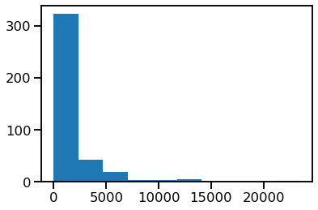

```python
plt.hist(coal["TOTAL EMPLOYMENT"])
```

Exploratory Data Visualizations

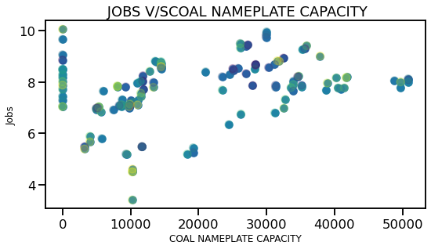

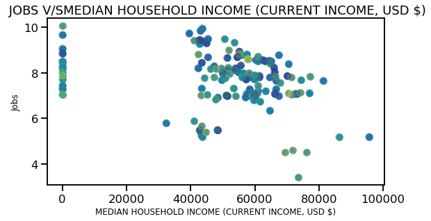

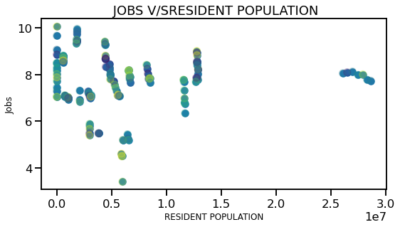

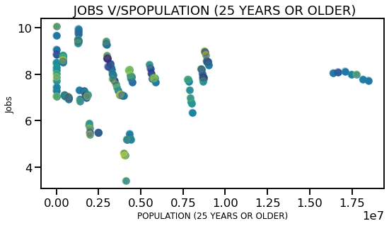

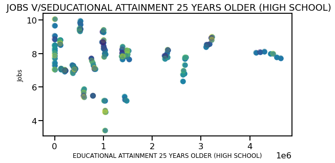

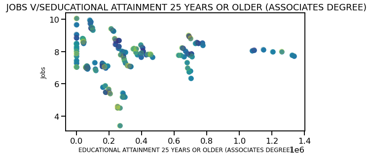

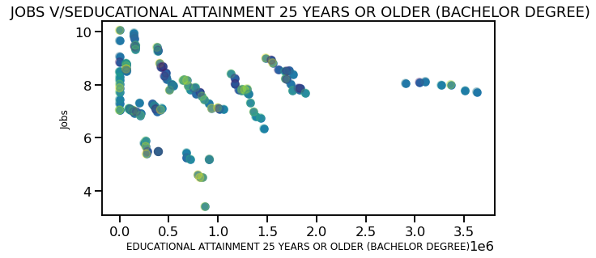

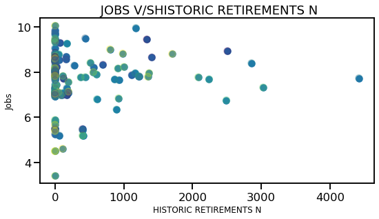

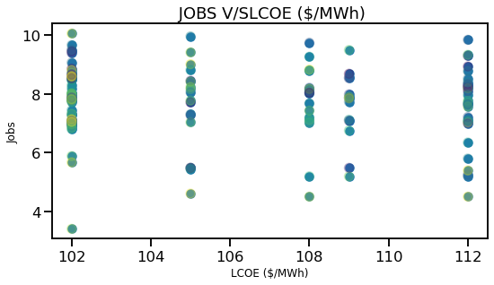

```python
#plotting some features with our output variable

features = ['COAL NAMEPLATE CAPACITY',
       'MEDIAN HOUSEHOLD INCOME (CURRENT INCOME, USD $)',
       'RESIDENT POPULATION', 'POPULATION (25 YEARS OR OLDER)',
       'EDUCATIONAL ATTAINMENT 25 YEARS OLDER (HIGH SCHOOL)',
       'EDUCATIONAL ATTAINMENT 25 YEARS OR OLDER (ASSOCIATES DEGREE)',
       'EDUCATIONAL ATTAINMENT 25 YEARS OR OLDER (BACHELOR DEGREE)',
       'HISTORIC RETIREMENTS N', 'LCOE ($/MWh)' ]

for i in features:

    plt.figure(figsize=(40,15))
    plt.subplot(3, 4,4)

    x = coal[i]
    y = np.log(coal['TOTAL EMPLOYMENT'])

    plt.scatter(x,y)
    rng = np.random.RandomState(0)
    colors = rng.rand(len(coal[i]))
    plt.scatter(x, y, c=colors, s=100, alpha=0.3,
            cmap='viridis')
    #plt.colorbar()
    plt.title(" JOBS V/S"+ i)
    plt.xlabel(i,fontsize=12)
    plt.ylabel("Jobs",fontsize=12)
    plt.show()

plt.tight_layout()
plt.show()
```

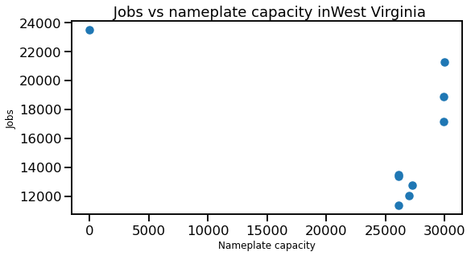

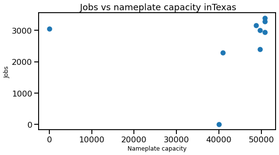

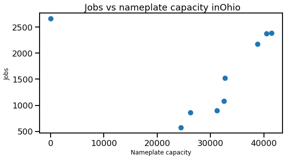

```python
st = ['West Virginia', 'Texas', 'Ohio' ]

for s in st:

    plt.figure(figsize=(40,15))
    plt.subplot(3, 4,4)

    x = coal.loc[coal['STATE']== s, 'COAL NAMEPLATE CAPACITY']
    y = coal.loc[coal['STATE']== s, 'TOTAL EMPLOYMENT']

    plt.scatter(x,y,)
    plt.title(" Jobs vs nameplate capacity in"+ s )
    plt.xlabel('Nameplate capacity',fontsize=12)
    plt.ylabel("Jobs",fontsize=12)
    plt.show()
```

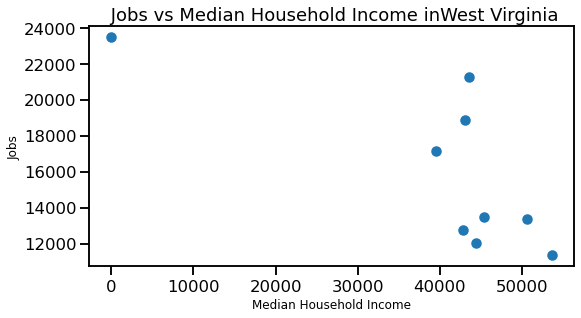

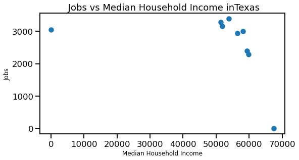

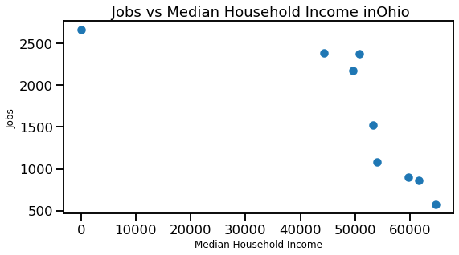

```python
st = ['West Virginia', 'Texas', 'Ohio' ]

for s in st:

    plt.figure(figsize=(40,15))
    plt.subplot(3, 4,4)

    x = coal.loc[coal['STATE']== s, 'MEDIAN HOUSEHOLD INCOME (CURRENT INCOME, USD $)']
    y = coal.loc[coal['STATE']== s, 'TOTAL EMPLOYMENT']

    plt.scatter(x,y,)
    plt.title(" Jobs vs Median Household Income in"+ s )
    plt.xlabel('Median Household Income',fontsize=12)
    plt.ylabel("Jobs",fontsize=12)
    plt.show()
```

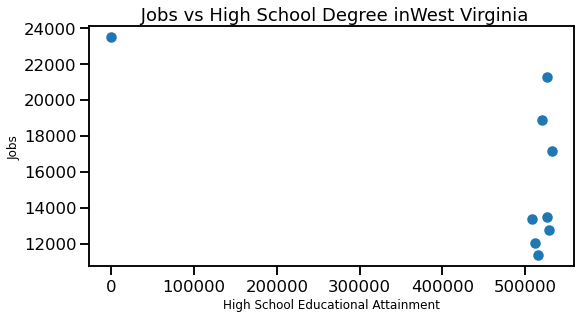

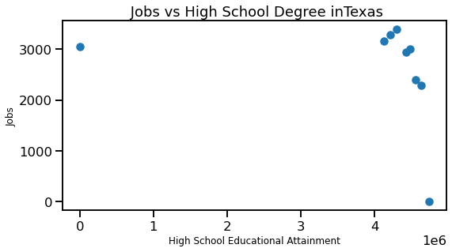

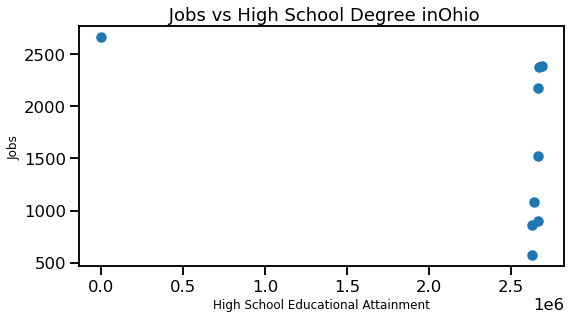

```python
st = ['West Virginia', 'Texas', 'Ohio' ]

for s in st:

    plt.figure(figsize=(40,15))
    plt.subplot(3, 4,4)

    x = coal.loc[coal['STATE']== s, 'EDUCATIONAL ATTAINMENT 25 YEARS OLDER (HIGH SCHOOL)']
    y = coal.loc[coal['STATE']== s, 'TOTAL EMPLOYMENT']

    plt.scatter(x,y,)
    plt.title(" Jobs vs High School Degree in"  + s )
    plt.xlabel('High School Educational Attainment',fontsize=12)
    plt.ylabel("Jobs",fontsize=12)
    plt.show()
```

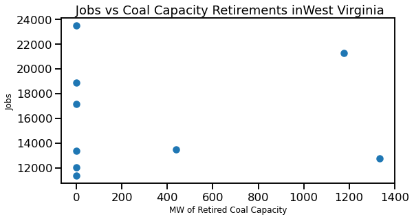

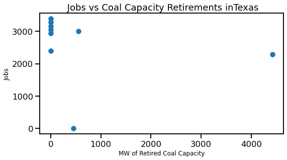

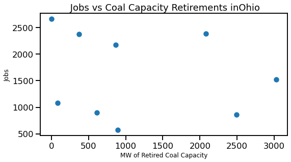

```python
st = ['West Virginia', 'Texas', 'Ohio' ]

for s in st:

    plt.figure(figsize=(40,15))
    plt.subplot(3, 4,4)

    x = coal.loc[coal['STATE']== s, 'HISTORIC RETIREMENTS N']
    y = coal.loc[coal['STATE']== s, 'TOTAL EMPLOYMENT']

    plt.scatter(x,y,)
    plt.title(" Jobs vs Coal Capacity Retirements in"+ s )
    plt.xlabel('MW of Retired Coal Capacity',fontsize=12)
    plt.ylabel("Jobs",fontsize=12)
    plt.show()
```

We made our state variables into dummies so they could be properly considered by the model.

```python
coal_dummy = pd.get_dummies(coal)
```